# STATS506 Final Project

## ADHCR and DHCR

```r
library(ggplot2)
library(dplyr)
library(survey)
data <- read.csv("C:/Users/Lenovo/Downloads/cbecs2018_final_public.csv")
data2 <- read.csv("C:/Users/Lenovo/Downloads/CBECS_FILTERED.csv")
```

```r
## First rename all variables to lower case
colnames(data) <- tolower(colnames(data))
```

```r
#rename levels of region
data$region <- as.factor(data$region)
levels(data$region) <- c("Northeast", "Midwest", "South", "West")

data$pubclim <- as.factor(data$pubclim)
levels(data$pubclim) <- c("Cold or very cold", "Cool", "Mixed mild", "Warm", "Hot or very hot", "withheld")

#We may delete those observations if nfloor is 994 or 995

data$renlgt <- as.factor(data$renlgt)
levels(data$renlgt) <- c("Yes", "No", "not applicable")

data$renelc <- as.factor(data$renelc)
levels(data$renelc) <- c("Yes", "No", "not applicable")
```

```r
# We first check if there is any NA in variable of "elhtbtu" and "elclbtu"
print(any(is.na(data$elhtbtu)))
```

```
[1] TRUE
```

```r
print(any(is.na(data$elclbtu)))
```

```
[1] TRUE
```

```r
# Then we will need to remove those observations that contains NA in these two variables
data <- data[which(!is.na(data$elhtbtu) & !is.na(data$elclbtu)),]
data$normal_ele <-(data$elexp - mean(data$elexp))/ sd(data$elexp)
data$elcns <- (data$elcns - mean(data$elcns))/ sd(data$elcns)
# find those building that never use electricity on heating or cooling
no_hc <- nrow(data[which(data$elclbtu == data$elhtbtu),])
no_hc
```

```
[1] 527
```

```r
# Now we construct two new columns named ratio and abs_ratio

ratio <- rep(NA, nrow(data))

for (i in 1 : nrow(data)){
  if (data$elhtbtu[i] > data$elclbtu[i]){
    ratio[i] <- (data$elhtbtu[i] - data$elclbtu[i])/data$elhtbtu[i]^(2/3)
  }

  if (data$elhtbtu[i] < data$elclbtu[i]){
    ratio[i] <- -(data$elclbtu[i] - data$elhtbtu[i])/data$elclbtu[i]^(2/3)
  }

  if (data$elhtbtu[i] == data$elclbtu[i]){
    ratio[i] <- 1
  }
}

data$ratio <- ratio
data$abs_ratio <- abs(ratio)
```

Since there are some building that never use any electricity on heating and cooling, I will remove them when I compute the descriptive statistics between different regions and climate zone.

```r
data_hc <- data[!(data$elclbtu== 0 & data$elhtbtu == 0),]
```

Now I have get the data_hc that contains all buildings that have cost on heating and cooling, since this data uses complex survey, I will first compute those basic statistics according to the variable “finalwt”

```r
weight_ratio_mean <- sum(data_hc$ratio * data_hc$finalwt) / sum(data_hc$finalwt)
weight_ratio_var <- sum(data_hc$finalwt * (data_hc$ratio - weight_ratio_mean)^2) /sum(data_hc$finalwt)

sorted_data <- data_hc[order(data_hc$ratio), ]

print(weight_ratio_mean)
```

```
[1] -18.50098
```

```r
print(weight_ratio_var)
```

```
[1] 1075.98
```

Now I will draw boxplot of the ratio for different region and climate zone, as well as their normalized electricity consumption

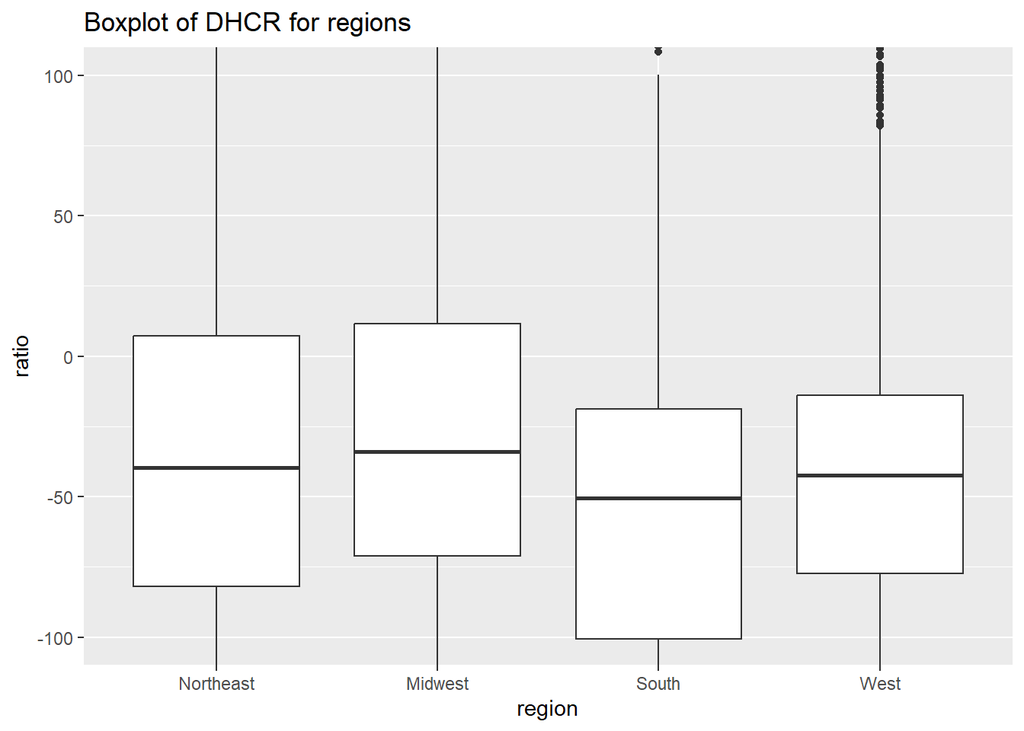

```r
ggplot(data_hc, aes(x = region, y = ratio)) + geom_boxplot() + labs(title = "Boxplot of DHCR for regions") + coord_cartesian(ylim = c(-100, 100))
```

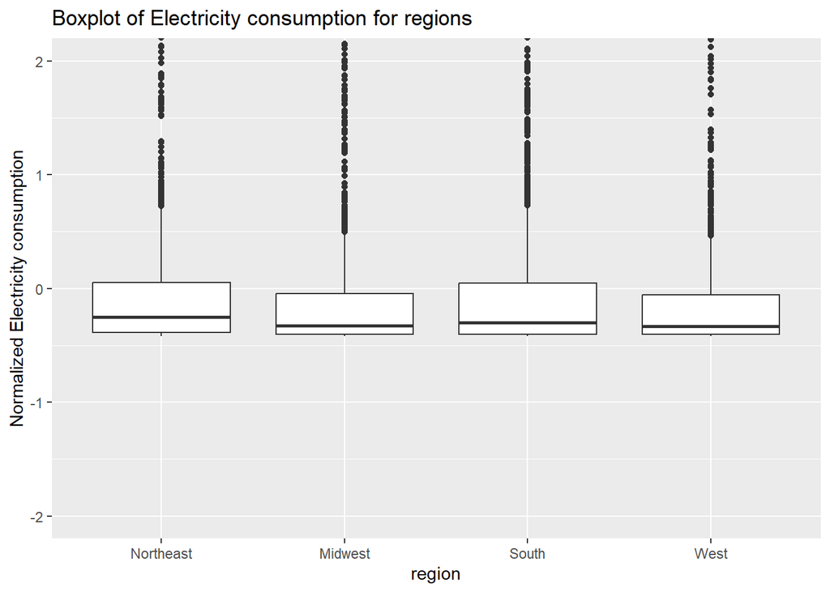

```r
box_ele_region <- ggplot(data_hc, aes(x = region, y = elcns)) +
  geom_boxplot() +
  labs(title = "Boxplot of Electricity consumption for regions") +
  ylab("Normalized Electricity consumption")

box_ele_region + coord_cartesian(ylim = c(-2, 2))
```

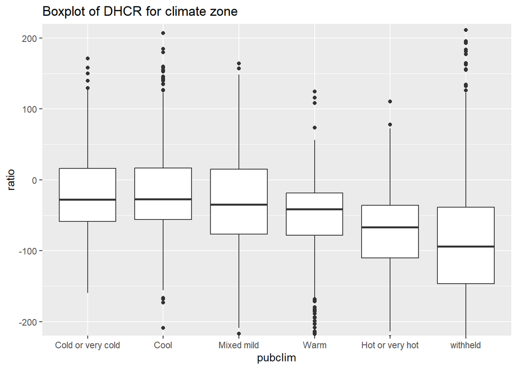

```r
ggplot(data_hc, aes(x = pubclim, y = ratio)) + geom_boxplot() + labs(title = "Boxplot of DHCR for climate zone") + coord_cartesian(ylim = c(-200, 200))
```

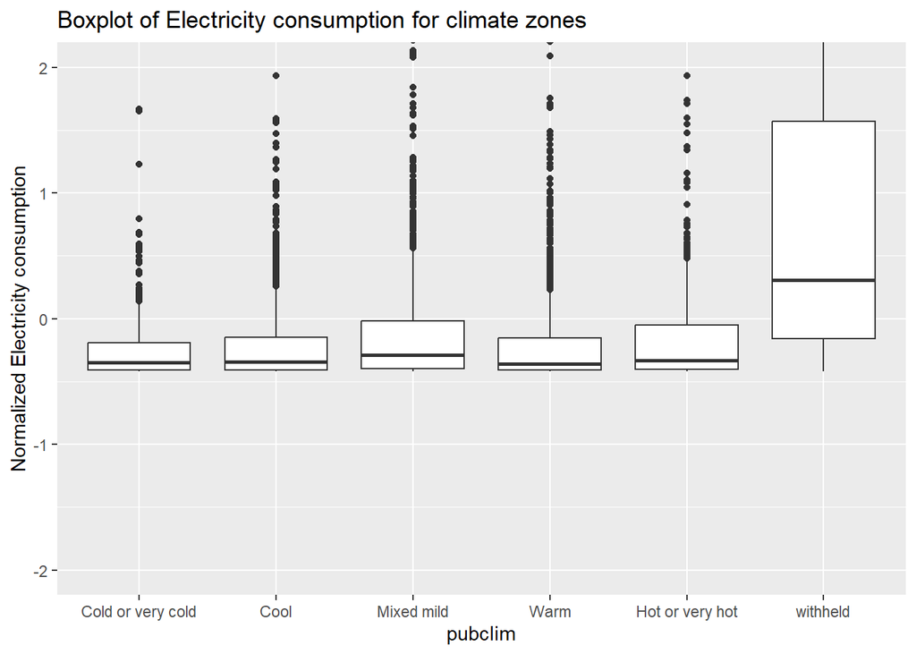

```r
box_ele_climate <- ggplot(data_hc, aes(x = pubclim, y = elcns)) +
  geom_boxplot() +
  labs(title = "Boxplot of Electricity consumption for climate zones") +
  ylab("Normalized Electricity consumption")

box_ele_climate + coord_cartesian(ylim = c(-2, 2))
```

Now I will take the absolute value of ratio and to check if there is difference between region and climate zone

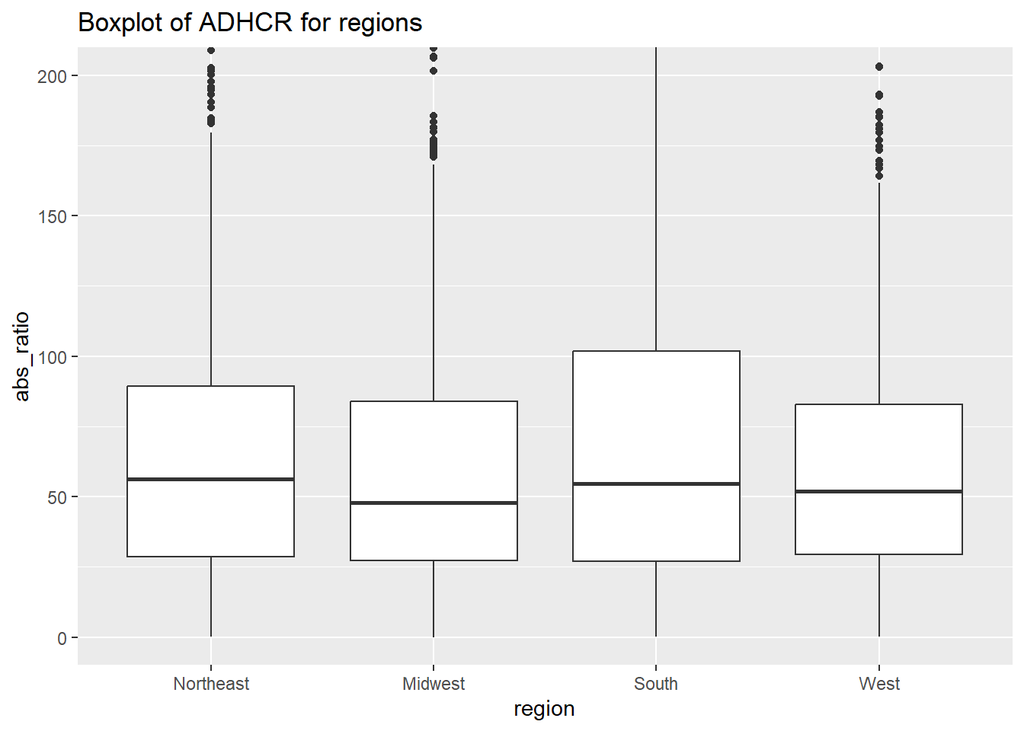

```r
ggplot(data_hc, aes(x = region, y = abs_ratio)) + geom_boxplot() + labs(title = "Boxplot of ADHCR for regions") + coord_cartesian(ylim = c(0, 200))
```

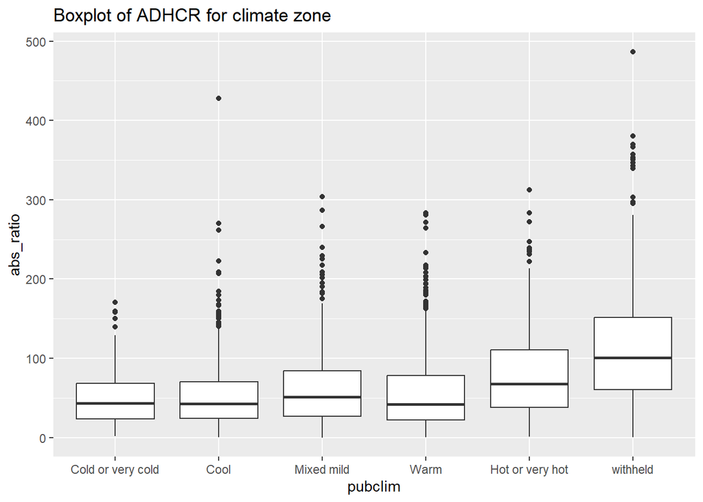

```r
ggplot(data_hc, aes(x = pubclim, y = abs_ratio)) + geom_boxplot() + labs(title = "Boxplot of ADHCR for climate zone")
```

Now I will explore the basic statistics of ratio and ratio_abs within each region and climate zone

```r
## ratio for region
ratio_region_table <- data_hc %>%
  group_by(region) %>%
  summarize(mean_DHCR = mean(ratio),
            median_DHCR = median(ratio),
            sd_DHCR = sd(ratio)) %>%
  ungroup()

ratio_region_table
```

```
# A tibble: 4 × 4
  region    mean_DHCR median_DHCR sd_DHCR
  <fct>         <dbl>       <dbl>   <dbl>
1 Northeast     -37.5       -39.7    71.8
2 Midwest       -28.2       -33.9    68.6
3 South         -61.9       -50.7    68.7
4 West          -40.8       -42.5    61.2
```

```r
## ratio for climate zone
ratio_climate_table <- data_hc %>%
  group_by(pubclim) %>%
  summarize(mean_DHCR = mean(ratio),
            median_DHCR = median(ratio),
            sd_DHCR= sd(ratio)) %>%
  ungroup()

ratio_climate_table
```

```
# A tibble: 6 × 4
  pubclim           mean_DHCR median_DHCR sd_DHCR
  <fct>                 <dbl>       <dbl>   <dbl>
1 Cold or very cold     -19.4       -27.8    56.0
2 Cool                  -18.8       -27.3    59.4
3 Mixed mild            -31.7       -34.7    64.6
4 Warm                  -51.2       -41.4    48.7
5 Hot or very hot       -75.5       -67.0    55.8
6 withheld              -87.6       -93.8    99.7
```

```r
## abs_ratio for region
abs_ratio_region_table <- data_hc %>%
  group_by(region) %>%
  summarize(mean_ADHCR = mean(abs_ratio),
            median_ADHCR = median(abs_ratio),
            sd_ADHCR = sd(abs_ratio)) %>%
  ungroup()

abs_ratio_region_table
```

```
# A tibble: 4 × 4
  region    mean_ADHCR median_ADHCR sd_ADHCR
  <fct>          <dbl>        <dbl>    <dbl>
1 Northeast       65.4         56.4     47.8
2 Midwest         59.7         47.8     44.0
3 South           71.3         54.6     58.9
4 West            60.4         51.8     41.9
```

```r
## normalized_consumption for region
ncons_region_table <- data_hc %>%
  group_by(region) %>%
  summarize(mean_cost = mean(elcns),
            median_cost = median(elcns),
            sd_cost = sd(elcns)) %>%
  ungroup()

ncons_region_table
```

```
# A tibble: 4 × 4
  region    mean_cost median_cost sd_cost
  <fct>         <dbl>       <dbl>   <dbl>
1 Northeast    0.0524      -0.254   0.974
2 Midwest     -0.0146      -0.326   1.04
3 South        0.0243      -0.299   1.01
4 West        -0.0434      -0.331   1.03
```

```r
## abs_ratio for climate
abs_ratio_climate_table <- data_hc %>%
  group_by(pubclim) %>%
  summarize(mean_ADHCR = mean(abs_ratio),
            median_ADHCR = median(abs_ratio),
            sd_ADHCR = sd(abs_ratio)) %>%
  ungroup()

abs_ratio_climate_table
```

```
# A tibble: 6 × 4
  pubclim           mean_ADHCR median_ADHCR sd_ADHCR
  <fct>                  <dbl>        <dbl>    <dbl>
1 Cold or very cold       50.0         43.1     31.8
2 Cool                    50.6         42.5     36.3
3 Mixed mild              59.1         51.2     41.0
4 Warm                    55.1         42.1     44.2
5 Hot or very hot         79.2         67.7     50.5
6 withheld               112.         101.      70.6
```

```r
## normalized_cost for climate
ncost_climate_table <- data_hc %>%
  group_by(pubclim) %>%
  summarize(mean_cost = mean(elcns),
            median_cost = median(elcns),
            sd_cost = sd(elcns)) %>%
  ungroup()

ncost_climate_table
```

```
# A tibble: 6 × 4
  pubclim           mean_cost median_cost sd_cost
  <fct>                 <dbl>       <dbl>   <dbl>
1 Cold or very cold   -0.199       -0.352   0.517
2 Cool                -0.199       -0.344   0.422
3 Mixed mild          -0.0965      -0.290   0.590
4 Warm                -0.166       -0.360   0.708
5 Hot or very hot     -0.148       -0.331   0.506
6 withheld             1.06         0.308   2.07
```

Now I will conduct ANOVA to test if the mean of abs_ratio within all regions are the same, and I will do the same thing to check it the abs_ratio within all climate zone are the same.

```r
table(data_hc$region[which(data_hc$pubclim == "withheld")])
```

```
Northeast   Midwest     South      West
      155       160       296       164
```

```r
anova_region <- aov(abs_ratio ~ region, data = data_hc)
summary(anova_region)
```

```
              Df   Sum Sq Mean Sq F value   Pr(>F)
region         3   152043   50681   19.83 8.72e-13 ***
Residuals   5826 14888671    2556
---
Signif. codes:  0 '***' 0.001 '**' 0.01 '*' 0.05 '.' 0.1 ' ' 1
```

```r
anova_climate <- aov(abs_ratio ~ pubclim, data = data_hc)
summary(anova_climate)
```

```
              Df   Sum Sq Mean Sq F value Pr(>F)
pubclim        5  2397305  479461   220.9 <2e-16 ***
Residuals   5824 12643409    2171
---
Signif. codes:  0 '***' 0.001 '**' 0.01 '*' 0.05 '.' 0.1 ' ' 1
```

So we can conclude not all region have the same average abs_ratio. And not all climate zone have the same average abs_ratio.

## Model Selection

```r
lm_1 <- lm(elcns ~ I(abs_ratio), data = data_hc)

summary(lm_1)
```

```
Call:
lm(formula = elcns ~ I(abs_ratio), data = data_hc)

Residuals:
    Min      1Q  Median      3Q     Max
-1.4174 -0.3221 -0.0748  0.1278 16.6749

Coefficients:
               Estimate Std. Error t value Pr(>|t|)
(Intercept)  -0.7178704  0.0179621  -39.97   <2e-16 ***
I(abs_ratio)  0.0110860  0.0002171   51.07   <2e-16 ***
---
Signif. codes:  0 '***' 0.001 '**' 0.01 '*' 0.05 '.' 0.1 ' ' 1

Residual standard error: 0.8419 on 5828 degrees of freedom
Multiple R-squared:  0.3091,    Adjusted R-squared:  0.309
F-statistic:  2608 on 1 and 5828 DF,  p-value: < 2.2e-16
```

Now I considered several predictors and now I will first introduce same variables I interested in that influence on normalized electricity cost.

```r
# first devide  SQFT by 1e^3 for stabalitity of our model
lmod_all <- lm(elcns ~ I(abs_ratio) + I(sqft/1000) + renelc + wkhrs +
                 pctermn + renlgt + monuse +  laptpn,  data = data_hc)

summary(lmod_all)
```

```
Call:
lm(formula = elcns ~ I(abs_ratio) + I(sqft/1000) + renelc + wkhrs +
    pctermn + renlgt + monuse + laptpn, data = data_hc)

Residuals:
    Min      1Q  Median      3Q     Max
-4.3248 -0.2510 -0.0214  0.1909 14.9185

Coefficients:
               Estimate Std. Error t value Pr(>|t|)
(Intercept)  -1.111e+00  2.033e-01  -5.464 5.08e-08 ***
I(abs_ratio)  3.933e-03  3.638e-04  10.808  < 2e-16 ***
I(sqft/1000)  1.699e-03  6.622e-05  25.664  < 2e-16 ***
renelcNo     -1.259e-01  3.740e-02  -3.367 0.000769 ***
wkhrs         3.486e-03  3.381e-04  10.313  < 2e-16 ***
pctermn       5.665e-04  4.049e-05  13.990  < 2e-16 ***
renlgtNo      7.097e-02  3.724e-02   1.906 0.056760 .
monuse        1.840e-02  1.739e-02   1.058 0.290156
laptpn       -3.056e-05  5.928e-05  -0.515 0.606269
---
Signif. codes:  0 '***' 0.001 '**' 0.01 '*' 0.05 '.' 0.1 ' ' 1

Residual standard error: 0.8365 on 2644 degrees of freedom
  (3177 observations deleted due to missingness)
Multiple R-squared:  0.5963,    Adjusted R-squared:  0.595
F-statistic: 488.1 on 8 and 2644 DF,  p-value: < 2.2e-16
```

```r
lmod <- update(lmod_all, . ~ . - laptpn)
summary(lmod)
```

```
Call:
lm(formula = elcns ~ I(abs_ratio) + I(sqft/1000) + renelc + wkhrs +
    pctermn + renlgt + monuse, data = data_hc)

Residuals:
    Min      1Q  Median      3Q     Max
-4.2549 -0.2259 -0.0144  0.1799 14.9537

Coefficients:
               Estimate Std. Error t value Pr(>|t|)
(Intercept)  -1.068e+00  1.733e-01  -6.161 8.17e-10 ***
I(abs_ratio)  3.878e-03  3.258e-04  11.903  < 2e-16 ***
I(sqft/1000)  1.651e-03  5.919e-05  27.901  < 2e-16 ***
renelcNo     -1.243e-01  3.324e-02  -3.738 0.000189 ***
wkhrs         3.167e-03  2.916e-04  10.861  < 2e-16 ***
pctermn       5.659e-04  3.498e-05  16.179  < 2e-16 ***
renlgtNo      7.281e-02  3.229e-02   2.255 0.024225 *
monuse        1.849e-02  1.485e-02   1.245 0.213377
---
Signif. codes:  0 '***' 0.001 '**' 0.01 '*' 0.05 '.' 0.1 ' ' 1

Residual standard error: 0.788 on 3054 degrees of freedom
  (2768 observations deleted due to missingness)
Multiple R-squared:  0.6008,    Adjusted R-squared:  0.5999
F-statistic: 656.6 on 7 and 3054 DF,  p-value: < 2.2e-16
```

```r
lmod <- update(lmod, . ~ . -  monuse)
summary(lmod)
```

```
Call:
lm(formula = elcns ~ I(abs_ratio) + I(sqft/1000) + renelc + wkhrs +
    pctermn + renlgt, data = data_hc)

Residuals:
    Min      1Q  Median      3Q     Max
-4.2570 -0.2293 -0.0190  0.1838 14.9556

Coefficients:
               Estimate Std. Error t value Pr(>|t|)
(Intercept)  -8.574e-01  3.837e-02 -22.343  < 2e-16 ***
I(abs_ratio)  3.860e-03  3.255e-04  11.857  < 2e-16 ***
I(sqft/1000)  1.656e-03  5.909e-05  28.022  < 2e-16 ***
renelcNo     -1.220e-01  3.320e-02  -3.676 0.000241 ***
wkhrs         3.224e-03  2.881e-04  11.189  < 2e-16 ***
pctermn       5.668e-04  3.497e-05  16.209  < 2e-16 ***
renlgtNo      7.205e-02  3.229e-02   2.231 0.025733 *
---
Signif. codes:  0 '***' 0.001 '**' 0.01 '*' 0.05 '.' 0.1 ' ' 1

Residual standard error: 0.7881 on 3055 degrees of freedom
  (2768 observations deleted due to missingness)
Multiple R-squared:  0.6006,    Adjusted R-squared:  0.5998
F-statistic: 765.6 on 6 and 3055 DF,  p-value: < 2.2e-16
```

```r
rmse <- function(x, y)sqrt(mean(x - y)^2)
```

We will then use AIC to select our model, but here we need to delete some rows since there are so many NA’sle

```r
data_aic <- data_hc[which(!is.na(data_hc$renelc) & !is.na(data_hc$pctermn) & !is.na(data_hc$wkhrs) & !is.na(data_hc$monuse) & !is.na(data_hc$laptpn)), ]

mod_aic <- lm(elcns ~ I(abs_ratio) + I(sqft/1000) + renelc + wkhrs +
                 pctermn + renlgt + monuse +  laptpn, data = data_aic)
step(mod_aic, direction = "both")
```

```
Start:  AIC=-938.33
elcns ~ I(abs_ratio) + I(sqft/1000) + renelc + wkhrs + pctermn +
    renlgt + monuse + laptpn

               Df Sum of Sq    RSS     AIC
- laptpn        1      0.19 1850.2 -940.07
- monuse        1      0.78 1850.8 -939.21
<none>                      1850.1 -938.33
- renlgt        1      2.54 1852.6 -936.69
- renelc        1      7.93 1858.0 -928.98
- wkhrs         1     74.41 1924.5 -835.71
- I(abs_ratio)  1     81.74 1931.8 -825.64
- pctermn       1    136.94 1987.0 -750.88
- I(sqft/1000)  1    460.86 2310.9 -350.23

Step:  AIC=-940.07
elcns ~ I(abs_ratio) + I(sqft/1000) + renelc + wkhrs + pctermn +
    renlgt + monuse

               Df Sum of Sq    RSS     AIC
- monuse        1      0.86 1851.1 -940.83
<none>                      1850.2 -940.07
+ laptpn        1      0.19 1850.1 -938.33
- renlgt        1      2.64 1852.9 -938.29
- renelc        1      7.90 1858.2 -930.76
- wkhrs         1     76.72 1927.0 -834.28
- I(abs_ratio)  1     81.56 1931.8 -827.63
- pctermn       1    152.88 2003.1 -731.45
- I(sqft/1000)  1    475.67 2325.9 -335.07

Step:  AIC=-940.83
elcns ~ I(abs_ratio) + I(sqft/1000) + renelc + wkhrs + pctermn +
    renlgt

               Df Sum of Sq    RSS     AIC
<none>                      1851.1 -940.83
+ monuse        1      0.86 1850.2 -940.07
+ laptpn        1      0.27 1850.8 -939.21
- renlgt        1      2.61 1853.7 -939.10
- renelc        1      7.70 1858.8 -931.81
- I(abs_ratio)  1     80.96 1932.1 -829.26
- wkhrs         1     81.63 1932.7 -828.34
- pctermn       1    153.56 2004.7 -731.40
- I(sqft/1000)  1    480.01 2331.1 -331.14
```

```
Call:
lm(formula = elcns ~ I(abs_ratio) + I(sqft/1000) + renelc + wkhrs +
    pctermn + renlgt, data = data_aic)

Coefficients:
 (Intercept)  I(abs_ratio)  I(sqft/1000)      renelcNo         wkhrs
  -0.9059429     0.0039065     0.0016971    -0.1239491     0.0035703
     pctermn      renlgtNo
   0.0005601     0.0717211
```

```r
mod_aic_final <- lm(elcns ~ I(abs_ratio) + I(sqft/1000)  + renelc+ wkhrs +
                 pctermn + renlgt, data = data_aic )
summary(mod_aic_final)
```

```
Call:
lm(formula = elcns ~ I(abs_ratio) + I(sqft/1000) + renelc + wkhrs +
    pctermn + renlgt, data = data_aic)

Residuals:
    Min      1Q  Median      3Q     Max
-4.2980 -0.2530 -0.0238  0.1974 14.9230

Coefficients:
               Estimate Std. Error t value Pr(>|t|)
(Intercept)  -9.059e-01  4.364e-02 -20.758  < 2e-16 ***
I(abs_ratio)  3.906e-03  3.631e-04  10.758  < 2e-16 ***
I(sqft/1000)  1.697e-03  6.479e-05  26.194  < 2e-16 ***
renelcNo     -1.239e-01  3.736e-02  -3.318 0.000919 ***
wkhrs         3.570e-03  3.305e-04  10.802  < 2e-16 ***
pctermn       5.601e-04  3.780e-05  14.816  < 2e-16 ***
renlgtNo      7.172e-02  3.716e-02   1.930 0.053702 .
---
Signif. codes:  0 '***' 0.001 '**' 0.01 '*' 0.05 '.' 0.1 ' ' 1

Residual standard error: 0.8364 on 2646 degrees of freedom
Multiple R-squared:  0.596, Adjusted R-squared:  0.5951
F-statistic: 650.7 on 6 and 2646 DF,  p-value: < 2.2e-16
```

```r
library(leaps)
mod_r <- regsubsets(elcns ~ I(abs_ratio) + I(sqft/1000) + renelc + wkhrs +
                 pctermn + renlgt + monuse +  laptpn,
                 data = data_hc)
```

```
Reordering variables and trying again:
```

```r
summary(mod_r)
```

```
Subset selection object
Call: regsubsets.formula(elcns ~ I(abs_ratio) + I(sqft/1000) + renelc +
    wkhrs + pctermn + renlgt + monuse + laptpn, data = data_hc)
10 Variables  (and intercept)
                     Forced in Forced out
I(abs_ratio)             FALSE      FALSE
I(sqft/1000)             FALSE      FALSE
renelcNo                 FALSE      FALSE
wkhrs                    FALSE      FALSE
pctermn                  FALSE      FALSE
renlgtNo                 FALSE      FALSE
monuse                   FALSE      FALSE
laptpn                   FALSE      FALSE
renelcnot applicable     FALSE      FALSE
renlgtnot applicable     FALSE      FALSE
1 subsets of each size up to 8
Selection Algorithm: exhaustive
         I(abs_ratio) I(sqft/1000) renelcNo renelcnot applicable wkhrs pctermn
1  ( 1 ) " "          "*"          " "      " "                  " "   " "
2  ( 1 ) " "          "*"          " "      " "                  " "   "*"
3  ( 1 ) " "          "*"          " "      " "                  "*"   "*"
4  ( 1 ) "*"          "*"          " "      " "                  "*"   "*"
5  ( 1 ) "*"          "*"          "*"      " "                  "*"   "*"
6  ( 1 ) "*"          "*"          "*"      " "                  "*"   "*"
7  ( 1 ) "*"          "*"          "*"      " "                  "*"   "*"
8  ( 1 ) "*"          "*"          "*"      " "                  "*"   "*"
         renlgtNo renlgtnot applicable monuse laptpn
1  ( 1 ) " "      " "                  " "    " "
2  ( 1 ) " "      " "                  " "    " "
3  ( 1 ) " "      " "                  " "    " "
4  ( 1 ) " "      " "                  " "    " "
5  ( 1 ) " "      " "                  " "    " "
6  ( 1 ) "*"      " "                  " "    " "
7  ( 1 ) "*"      " "                  "*"    " "
8  ( 1 ) "*"      " "                  "*"    "*"
```

R^2

```r
which.max(summary(mod_r)$adjr2)
```

```
[1] 7
```

```r
summary(mod_r)$adjr2
```

```
[1] 0.5061136 0.5448939 0.5762729 0.5936482 0.5946937 0.5951105 0.5951467
[8] 0.5950342
```

```r
mod_r_2 <- lm(elcns ~ I(abs_ratio) + I(sqft/1000) + renelc + wkhrs +
                 pctermn + renlgt + monuse, data = data_hc)
summary(mod_r_2)
```

```
Call:
lm(formula = elcns ~ I(abs_ratio) + I(sqft/1000) + renelc + wkhrs +
    pctermn + renlgt + monuse, data = data_hc)

Residuals:
    Min      1Q  Median      3Q     Max
-4.2549 -0.2259 -0.0144  0.1799 14.9537

Coefficients:
               Estimate Std. Error t value Pr(>|t|)
(Intercept)  -1.068e+00  1.733e-01  -6.161 8.17e-10 ***
I(abs_ratio)  3.878e-03  3.258e-04  11.903  < 2e-16 ***
I(sqft/1000)  1.651e-03  5.919e-05  27.901  < 2e-16 ***
renelcNo     -1.243e-01  3.324e-02  -3.738 0.000189 ***
wkhrs         3.167e-03  2.916e-04  10.861  < 2e-16 ***
pctermn       5.659e-04  3.498e-05  16.179  < 2e-16 ***
renlgtNo      7.281e-02  3.229e-02   2.255 0.024225 *
monuse        1.849e-02  1.485e-02   1.245 0.213377
---
Signif. codes:  0 '***' 0.001 '**' 0.01 '*' 0.05 '.' 0.1 ' ' 1

Residual standard error: 0.788 on 3054 degrees of freedom
  (2768 observations deleted due to missingness)
Multiple R-squared:  0.6008,    Adjusted R-squared:  0.5999
F-statistic: 656.6 on 7 and 3054 DF,  p-value: < 2.2e-16
```